# A3: Incarceration

### Introduction

The problem of incarceration has been plaguing the United States for decades now, especially the disproportionate policing rates of people of color. We will explore these rates and percentages, specifically the statistics pertaining to White and Black people. These two polarizing groups make up the majority the US population and represent two parties, those in power and those void of power. Some variables that we will be focusing on are how the populations of these two groups have changed in prison. We will also be keeping track of the population proportion of the two groups in prison and how those have changed over time. Exploring these variables will help viewers have a better understanding of the disproportionate rates of incarceration that is occurring in the United States. We will be tracking these statistics using data from prisoners from ages 15 - 64 years old, as this age range has the most accurate data to work with.

### Summary Information

Looking at the data of prisoners from the age of 15-64, we can see a lot of differences between the population of White and Black prisoners. **In 1990, we found that the average population of prisoners was 52313**, while the **average in 2018 was 68127**, which was an **average increase of 30.23%**. This increase was concerning, but when we looked at the average population increase of Black and White prisoners, we found a much larger problem. In **1990, the average population of Black prisoners was 6053**, while the **average in 2018 was 9186**, which was a whopping **51.76% average increase**. If we compare this to **White prisoners, in 1990, their average population was 39626**, while in **2018 their average was 41094.82**, making it only a **3.71% average increase**. These percentages stick out like a sore thumb and it prompts us to think of why this is.

### The Dataset

Who collected the data?

- Vera Institute

How was the data collected or generated?

- The dataset was assembled using information collected by the U.S. Department of Justice Bureau of Justice Statistics (BJS), supplemented with data from state departments of correction when federal data is not available.

Why was the data collected?

- The data was collected to observe the incarceration rates among different demographics in prisons and jails.

How many observations (rows) are in your data?

- There are 153,811 observations in the data.

How many features (columns) are in the data?

- There are 36 features in the data.

What, if any, ethical questions or questions of power do you need to consider when working with this data?

- When working with this data, we need to make sure that we don’t create any biases within our work by excluding or including certain data, otherwise known as cherry-picking.

What are possible limitations or problems with this data?

- A big limitation in this dataset is that there are a lot of years where certain pieces of data are missing. This causes problems because we will naturally have to cherry-pick years that our data comes from due to the fact that certain data is missing from certain years. Problems will emerge where we need to constantly check if data from a certain year is available to us and make changes accordingly. Another big problem with this data is that it is a compilation of different sources, coming from the Nations Corrections Reporting Program (NCRP), the Deaths in Custody Reporting Program (DCRP) the Annual Survey of Jails (ASJ), the Census of Jails (COJ), the Centers for Disease Control and Prevention (CDC), the U.S. Department of Agriculture (USDA), and the U.S. Census Bureau. This is a problem because they have different methods and criteria for collecting data, which can lead to discrepancies in the dataset. For example, the geographic data from the USDA and U.S. Census Bureau may be different from the population data from the NCRP, which will cause our work to be much different from reality. Although this is a possible problem, the data provided from the USDA and U.S. Census Bureau makeup the least amount of the data in the set, so the problem is more likely to be smaller.

### Trends Over Time Chart

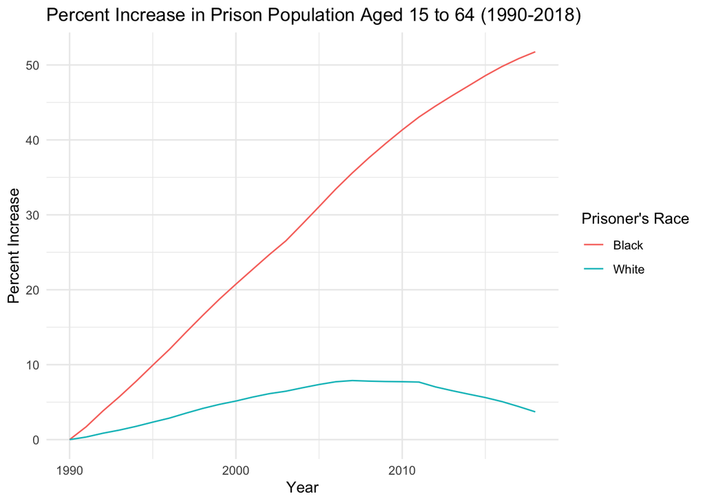

In this chart we can see the percent increase of Black and White prisoners starting from 1990 to 2018. The graph shows a stark contrast between Black and White prisoners, where Black prisoners end up over 50% increase, while White prisoners end at under 5% in 2018.

### Variable Comparison Chart

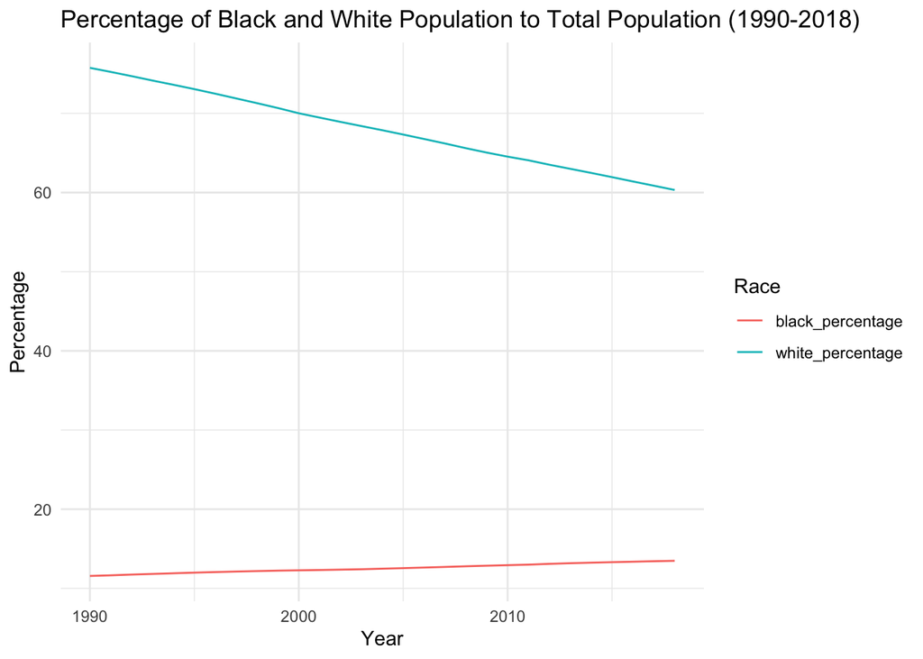

### Map

[figure not shown]